# R Notebook

2022 November 18 Jacob Cram

We just got data back from UC davis of carbon and nitrogne content of particles. This file is for examining that data

I refer to things as “Molarity” a lot here, including in the title, because I originally though the measurments were in moles/L. They are not, everything is in mg/L. The units in the figures should be correct.

2023 March 20 – I’m updating the figure S2 – MCN_Molarity.png to correct the units.

```r
library(tidyverse)
library(here)
library(readxl)
library(cowplot)
library(grid)
library(gridExtra)
#source(here::here("RScripts","ElementalAnalysis.R"))
load(here::here("RDataFiles", "microbialAbundance.RData"))
my_sizes <- sort(unique(microbialAbundance$Size_Class))
source(here::here("RLibraries", "ChesapeakePersonalLibrary.R"))

# This operation stopped sticking for some reaon, so I'm redoing it.
microbialAbundance <- microbialAbundance %>%
  mutate(Depth = ordered(Depth, levels = c("Surface", "Oxycline", "Bottom")))
```

I’m not subtracting blanks for now (on account of they are pretty small)

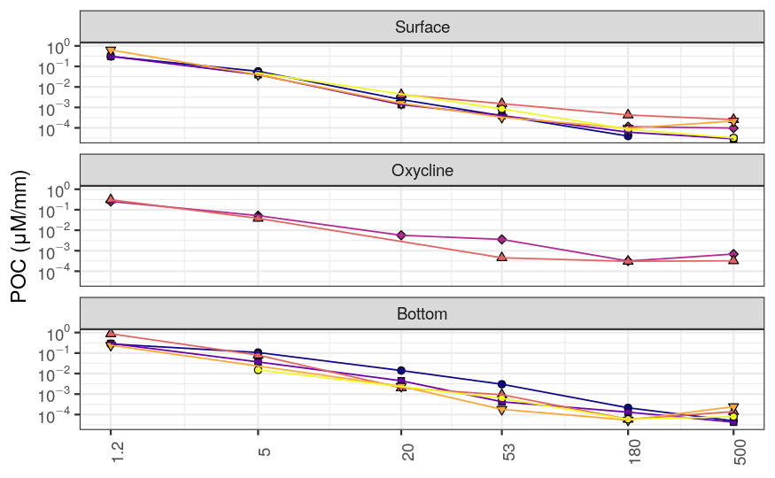

```r
ches_plot_options2 <- list(
  #scale_y_log10nice() ,
  scale_x_log10(breaks = my_sizes, labels = as.character(my_sizes)) ,
  geom_point(size = 2) ,
  geom_path(aes(color = as.factor(Station))) ,
  scale_shape_manual(values = rep(21:25, 2)) ,
  scale_fill_viridis_d(option = "plasma") ,
  scale_color_viridis_d(option = "plasma")
)

cb_plotter <- function(Variable, logify = TRUE, lab){
  EVariable <- enquo(Variable)

  plt0 <- microbialAbundance %>%
    #filter(Type == "Sample") %>%
    filter(!is.na(Station)) %>%
    arrange(Size_Class) %>%
    filter(Size_Class != 0.2) %>%
    #filter(Depth != "Oxy") %>%
    ggplot(aes(y = !!EVariable, x = Size_Class, shape = as.factor(Station), fill = as.factor(Station))) +
    geom_point() +
    facet_wrap(~as.factor(Depth), ncol = 1) +
    ches_plot_options2 +
    theme_bw(base_size = 14) +
    theme(legend.position = "none", axis.title.x = element_blank(), axis.text.x = element_text(angle = 90)) +
    labs(y = lab)

  if(logify){
    plt1 <- plt0 + scale_y_log10nice()
  }else{
    plt1 <- plt0
  }

  plt1
}
cb_plotter(CarbonPerLiter_mg/Bin_Size, logify = TRUE, lab = "POC (μM/mm)")
```

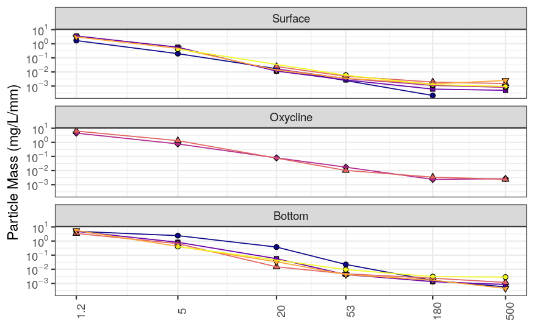

```r
cb_plotter(MassperLiter/Bin_Size, logify = TRUE, lab = "Particle Mass (mg/L/mm)")
```

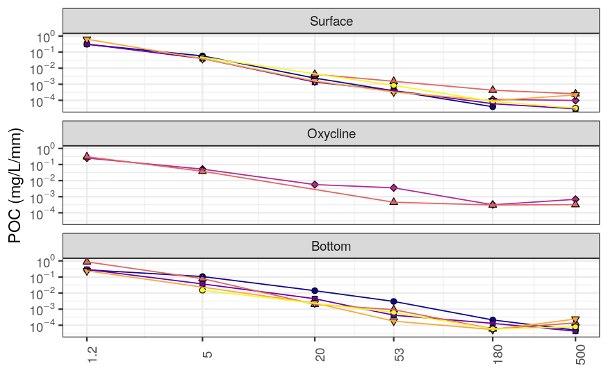

```r
# cb_plotter(ParticlesPerLiter/Bin_Size, logify = TRUE, lab = "Particle Abundance (#/L/mm)") -- This has been linearalized at some point. Not buying it.
cb_plotter(CarbonPerLiter_mg/Bin_Size, logify = TRUE, lab = "POC (mg/L/mm)")
```

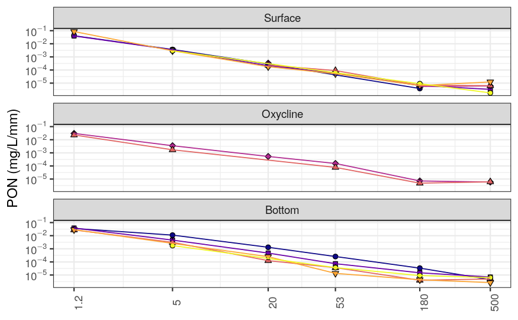

```r
cb_plotter(NitrogenPerLiter_mg/Bin_Size, logify = TRUE, lab = "PON (mg/L/mm)")
```

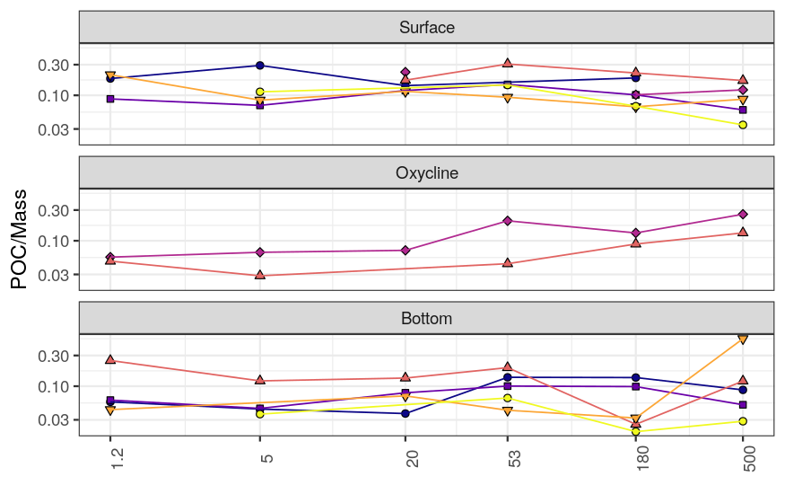

```r
cb_plotter(CarbonPerLiter_mg/MassperLiter, logify = FALSE, lab = "POC/Mass") + scale_y_log10()
```

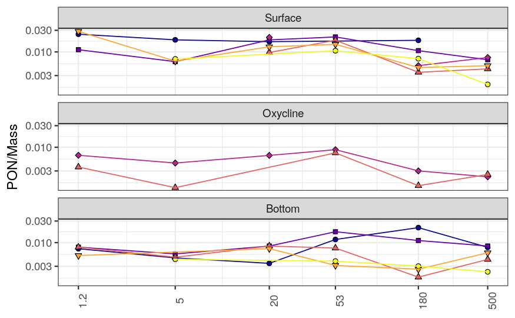

```r
cb_plotter(NitrogenPerLiter_mg/MassperLiter, logify = FALSE, lab = "PON/Mass") + scale_y_log10()
```

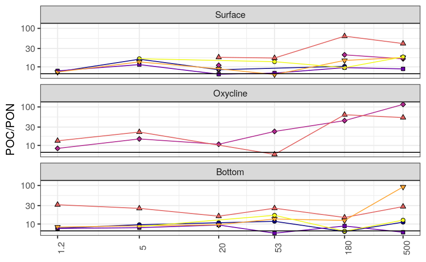

```r
cb_plotter(CarbonPerLiter_mg/NitrogenPerLiter_mg, logify = FALSE, lab = "POC/PON") + geom_hline(yintercept = 106/16)  + scale_y_log10()
```

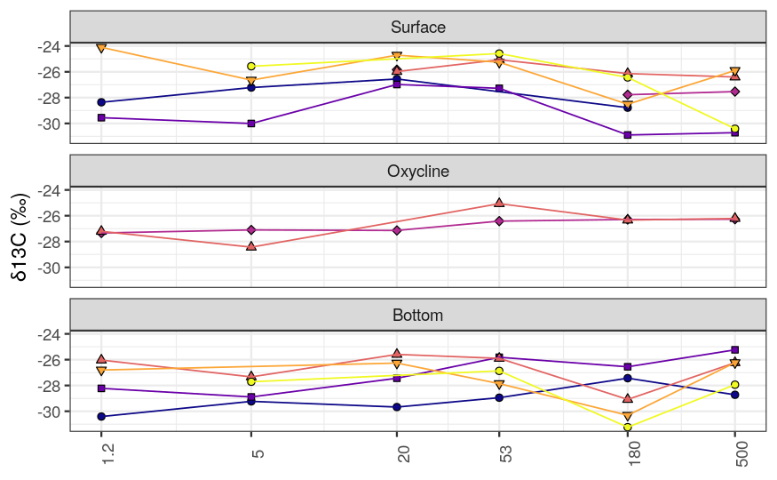

```r
cb_plotter(`δ13CVPDB (‰)`, logify = FALSE, lab = "δ13C (‰)")
```

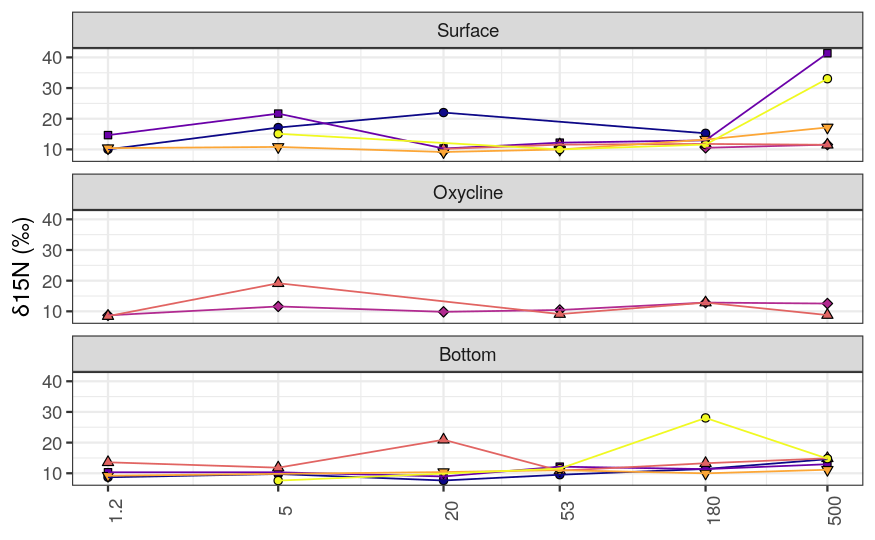

```r
cb_plotter(`δ15NAir (‰)`, logify = FALSE, lab = "δ15N (‰)")
```

I think I want three plots – all will be supplementary probably

Fig SX: Mass, moles C, moles N Fig SX + 1: C/mass, N/mass, C:N Fig SX + 2: delta 13c and delta 15n

Fig SX: Mass, moles C, moles N

x.grob <- textGrob(expression(paste(“Particle Size (”, mu, “m)”)), gp=gpar(fontsize=14))

combinedPlot <- plot_grid(abunPlot_perL, abunPlot_perMg, nrow = 1, labels = c(“B”, “C”)) combinedPlot_xg <- grid.arrange(arrangeGrob(combinedPlot, x.grob, heights = c(10, 1)))

Function to add a common x label

```r
append_xg <- function(plt, txt = expression(paste("Particle Size (", mu, "m)"))){
  x.grob0 <- textGrob(expression(paste("Particle Size (", mu, "m)")),
                   gp=gpar(fontsize=14))
  plot_xg <- grid.arrange(arrangeGrob(plt, x.grob0, heights = c(10, 1)))
}
```

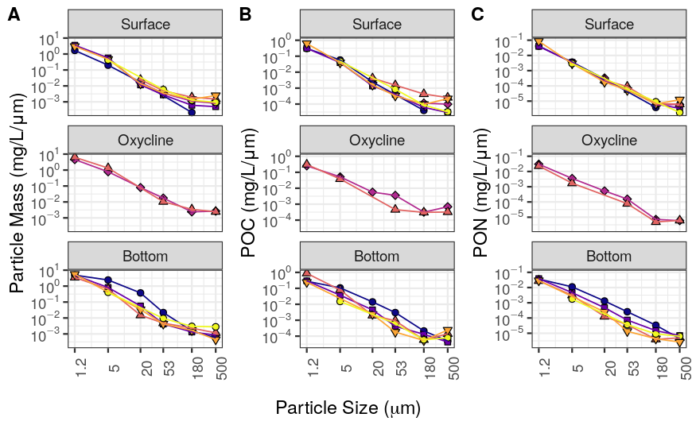

```r
molarityPlot0 <- plot_grid(
  cb_plotter(MassperLiter/Bin_Size, logify = TRUE, lab = "Particle Mass (mg/L/μm)"),
  cb_plotter(CarbonPerLiter_mg/Bin_Size, logify = TRUE, lab = "POC (mg/L/μm)"),
  cb_plotter(NitrogenPerLiter_mg/Bin_Size, logify = TRUE, lab = "PON (mg/L/μm)"),
  nrow = 1,
  labels = LETTERS
)
molarityPlot <- append_xg(molarityPlot0)
```

```r
ggsave(here::here("Figures", "MCN_Molarity.png"), plot = molarityPlot, height = 4, width = 6)
```

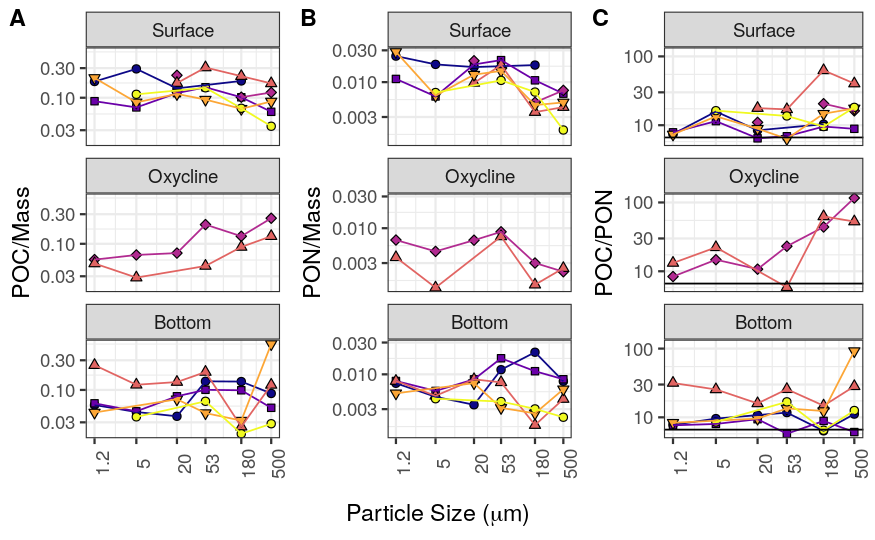

```r
ratioPlot <- plot_grid(
  cb_plotter(CarbonPerLiter_mg/MassperLiter, logify = TRUE, lab = "POC/Mass") + scale_y_log10(),
  cb_plotter(NitrogenPerLiter_mg/MassperLiter, logify = TRUE, lab = "PON/Mass") + scale_y_log10(),
  cb_plotter(CarbonPerLiter_mg/NitrogenPerLiter_mg, logify = TRUE, lab = "POC/PON") + scale_y_log10() + geom_hline(yintercept = 106/16),
  nrow = 1,
  labels = LETTERS
) %>% append_xg()
```

```r
ggsave(here::here("Figures", "MCN_Ratios.png"), plot = ratioPlot, height = 4, width = 6)
```

C:N Cite Van Mooy

[figure not shown]

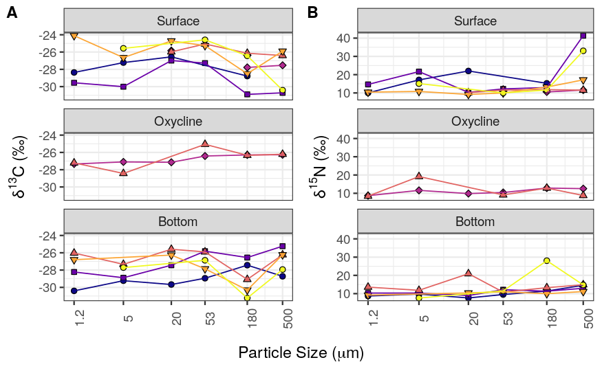

```r
deltaCNPlot <- plot_grid(
  cb_plotter(`δ13CVPDB (‰)`, logify = FALSE, lab = bquote(`δ`^{13}*'C (‰)')),
  cb_plotter(`δ15NAir (‰)`, logify = FALSE, lab = bquote(`δ`^{15}*'N (‰)')),
  nrow = 1,
  labels = LETTERS
) %>% append_xg()
```

```r
ggsave(here::here("Figures", "CN_IsotopeRatios.png"), plot = deltaCNPlot, height = 4, width = 4)
```

Clara says 40 delta 15N is very very high.

# Primary figure

Happens over in ActiveNotebooks/AllMicrobesFigures.qmd

# Carbon to nitrogen ratios for all of the particles

So I can say how C:N vary across space

```r
microbialAbundance %>%
  select(Station, Size_Class, Depth, CarbonPerLiter_mg, NitrogenPerLiter_mg) %>%
  pivot_longer(cols = c(CarbonPerLiter_mg, NitrogenPerLiter_mg), names_to = "measurement", values_to = "mg") %>%
  filter(Size_Class>0.2) %>%
  #filter(is.na(mg)) %>%
  group_by(Station, Depth, measurement) %>%
  summarise(mg = sum(mg)) %>%
  pivot_wider(names_from = measurement, values_from = mg) %>%
  mutate(CtoN = CarbonPerLiter_mg/NitrogenPerLiter_mg) %>%
  identity()
```

| Station | Depth | CarbonPerLiter_mg | NitrogenPerLiter_mg | CtoN |
| --- | --- | --- | --- | --- |
| 3.1 | Surface | 2.1160169 | 0.22145823 | 9.554926 |
| 3.1 | Bottom | 3.5887952 | 0.39069209 | 9.185738 |
| 3.2 | Surface | 1.9086831 | 0.22065957 | 8.649899 |
| 3.2 | Bottom | 1.9341477 | 0.24814144 | 7.794537 |
| 3.3 | Surface | NA | NA | NA |
| 3.3 | Oxycline | 2.8191140 | 0.20956428 | 13.452263 |
| 4.3 | Surface | 0.5950405 | 0.02452187 | 24.265703 |
| 4.3 | Oxycline | 2.0449026 | 0.12791033 | 15.987002 |
| 4.3 | Bottom | 4.7619472 | 0.16374180 | 29.082050 |
| 5.1 | Surface | 3.2119665 | 0.39045309 | 8.226254 |

[output cut: 3 more lines]